# Explore and Summarize Data by Yongnan Sun

[Download data](https://www.google.com/url?q=https://s3.amazonaws.com/udacity-hosted-downloads/ud651/wineQualityReds.csv&sa=D&ust=1504549612426000&usg=AFQjCNHlCZXexmiYS4VWtm1qqupA4JiUsQ)

# Introduction

This tidy data set contains 1,599 red wines with 11 variables on the chemical properties of the wine. At least 3 wine experts rated the quality of each wine, providing a rating between 0 (very bad) and 10 (very excellent).

This dataset is public available for research. The details are described in [Cortez et al., 2009].

Available at: [@Elsevier] http://dx.doi.org/10.1016/j.dss.2009.05.016

# Summary wine data

```
## 'data.frame':    1599 obs. of  12 variables:
##  $ fixed.acidity       : num  7.4 7.8 7.8 11.2 7.4 7.4 7.9 7.3 7.8 7.5 ...
##  $ volatile.acidity    : num  0.7 0.88 0.76 0.28 0.7 0.66 0.6 0.65 0.58 0.5 ...
##  $ citric.acid         : num  0 0 0.04 0.56 0 0 0.06 0 0.02 0.36 ...
##  $ residual.sugar      : num  1.9 2.6 2.3 1.9 1.9 1.8 1.6 1.2 2 6.1 ...
##  $ chlorides           : num  0.076 0.098 0.092 0.075 0.076 0.075 0.069 0.065 0.073 0.071 ...
##  $ free.sulfur.dioxide : num  11 25 15 17 11 13 15 15 9 17 ...
##  $ total.sulfur.dioxide: num  34 67 54 60 34 40 59 21 18 102 ...
##  $ density             : num  0.998 0.997 0.997 0.998 0.998 ...
##  $ pH                  : num  3.51 3.2 3.26 3.16 3.51 3.51 3.3 3.39 3.36 3.35 ...
##  $ sulphates           : num  0.56 0.68 0.65 0.58 0.56 0.56 0.46 0.47 0.57 0.8 ...
##  $ alcohol             : num  9.4 9.8 9.8 9.8 9.4 9.4 9.4 10 9.5 10.5 ...
##  $ quality             : int  5 5 5 6 5 5 5 7 7 5 ...
```

Our dataset consists of 12 variables, with 1599 observations. Quality variable is discrete and the others are continuous.

# Univariate Plots Section

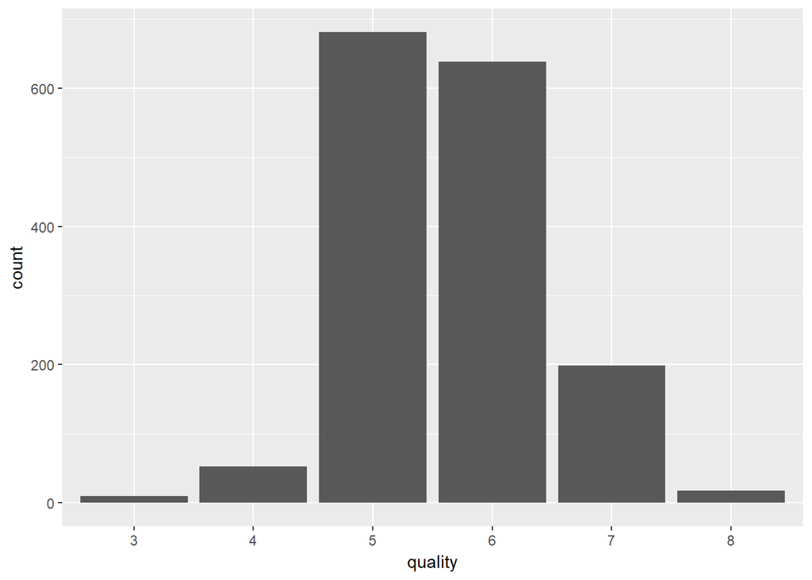

```
##    Min. 1st Qu.  Median    Mean 3rd Qu.    Max.
##   3.000   5.000   6.000   5.636   6.000   8.000
```

Red wine quality is normally distributed and concentrated around 5 and 6.

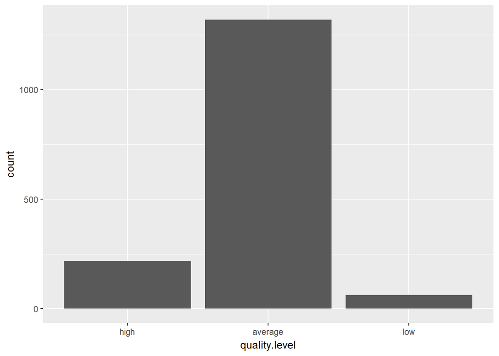

```
##    high average     low
##     217    1319      63
```

Explore the new variable we created.

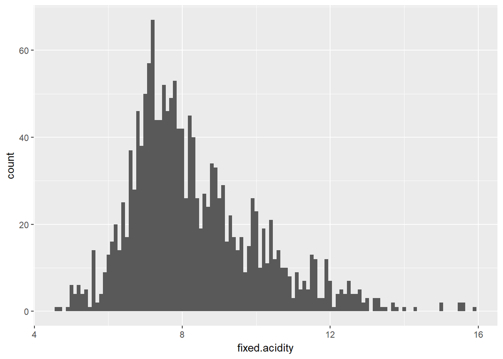

The distribution of fixed acidity is right skewed, and concentrated around 7.9.

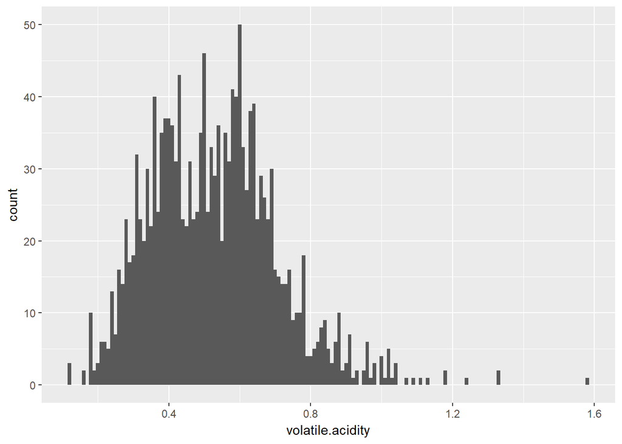

The distribution of volatile acidity seems to be unclear whether it is bimodal or unimodel, right skewed or normal.

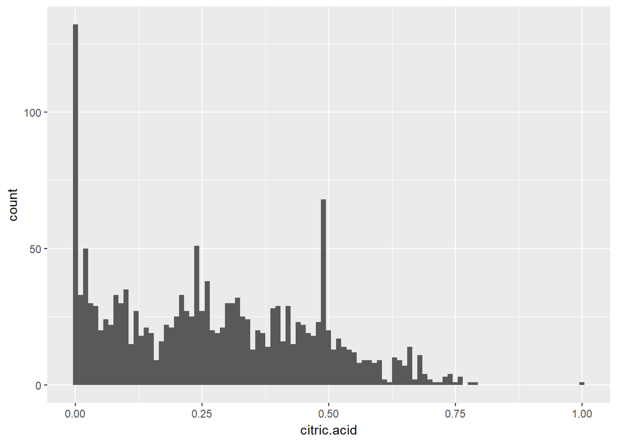

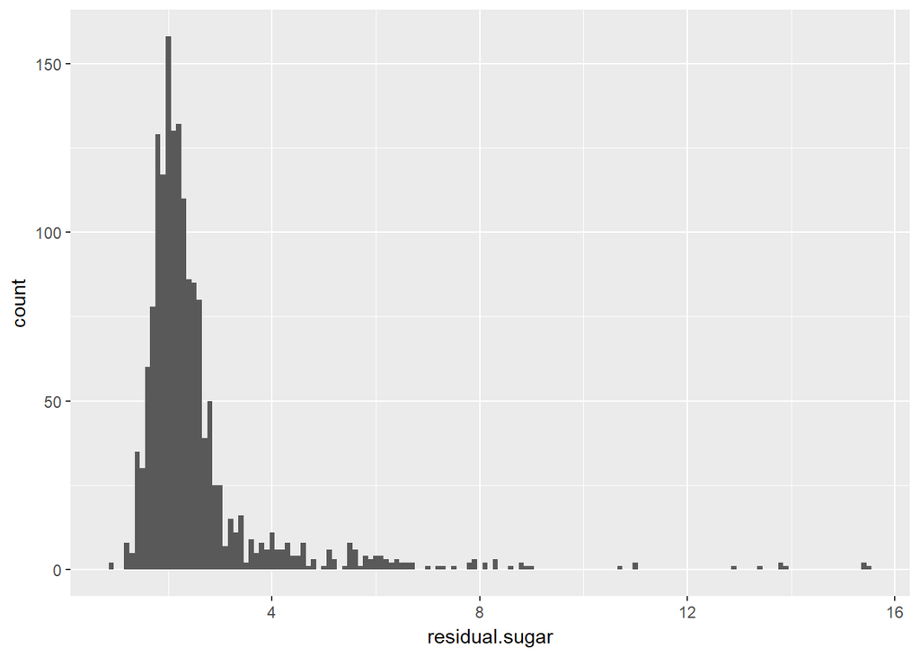

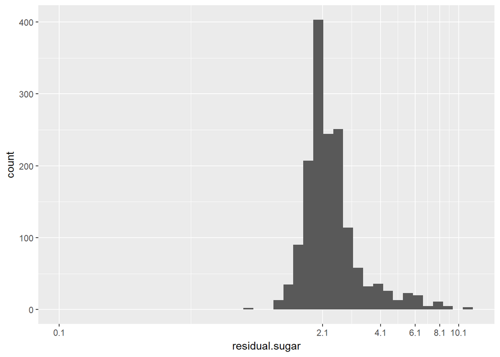

The distribution of residual sugar is right skewed, and concentrated around 2. There are a few outliers in the plot. Using scale_x_log10() transformer we see the distribution is close to normal. It can be considered a lognormal distribution.

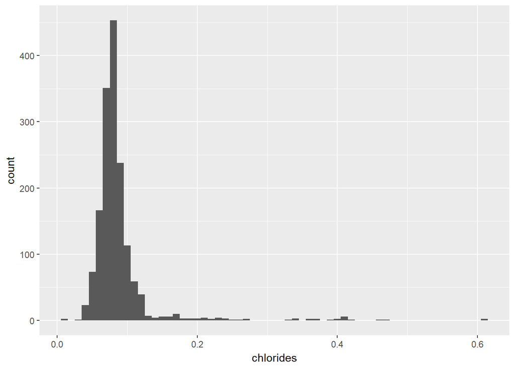

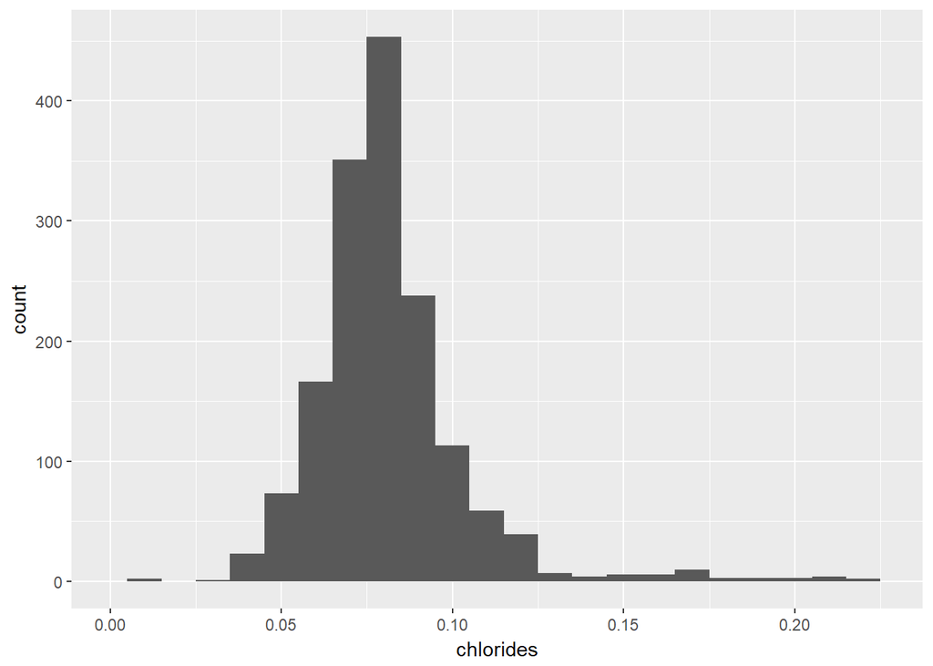

If we remove the top 2 percent chlorides(outlies) we can see the distribution is nearly a normal, and concentrated around 0.08.

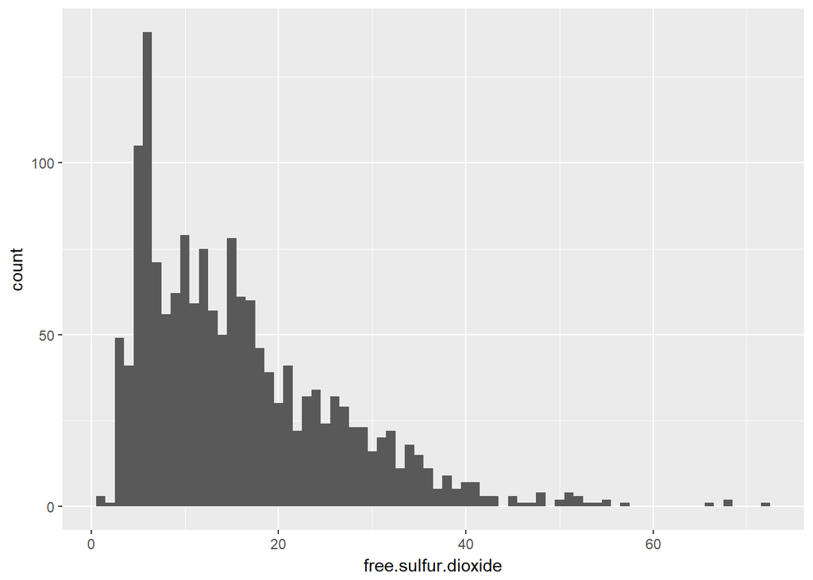

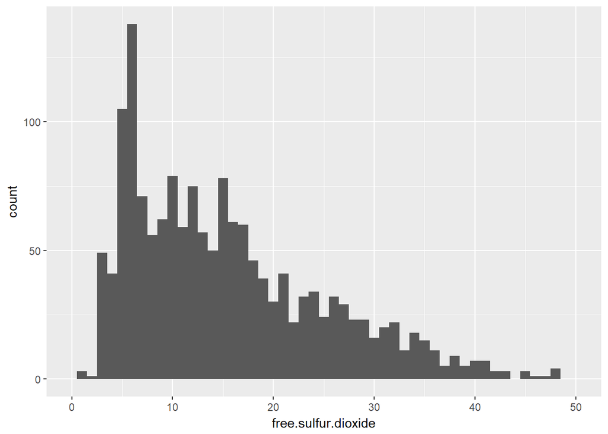

The distribution of free sulfur dioxide is right skewed and concentrated around 14. The second plot removed top 1 percent of outliers.

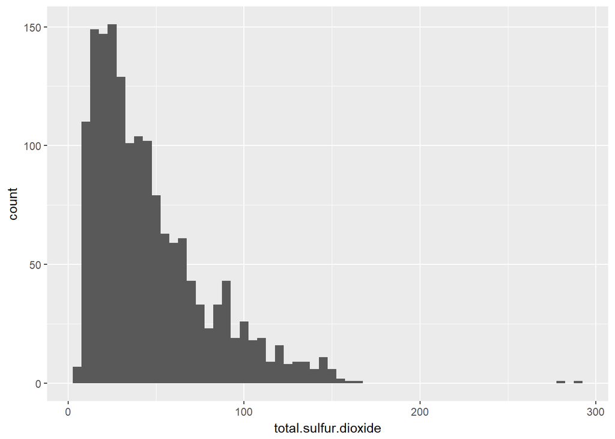

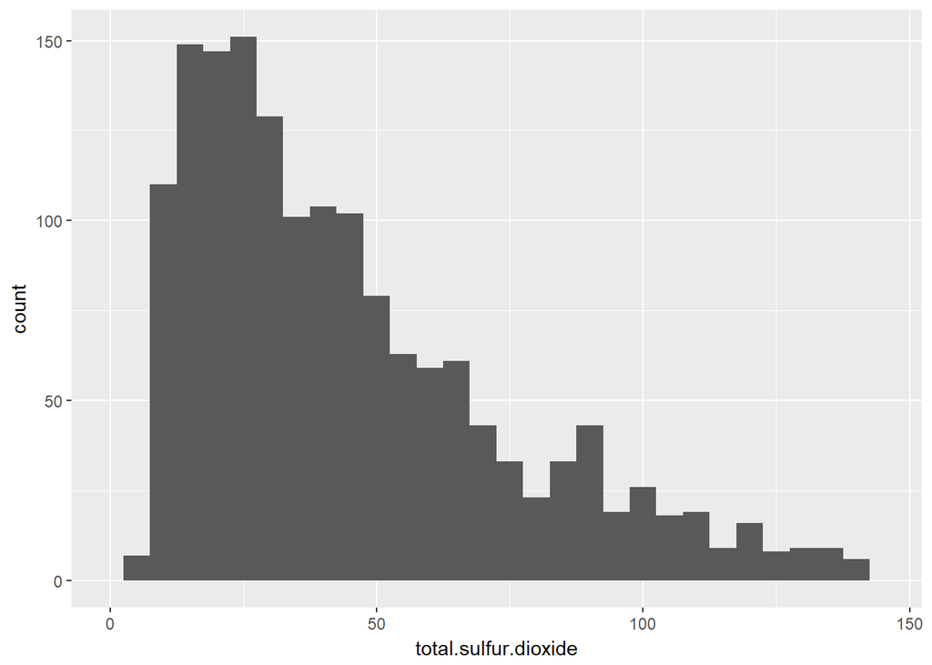

The distribution of total sulfur dioxide is right skewed and concentrated around 38. The second plot removed top 1 percent of outliers.

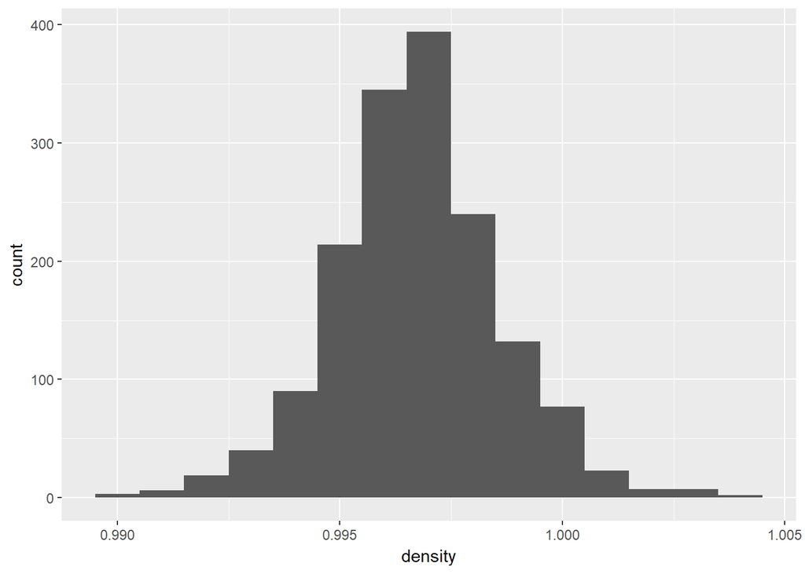

The distribution of density is normal and concentrated around 0.9967.

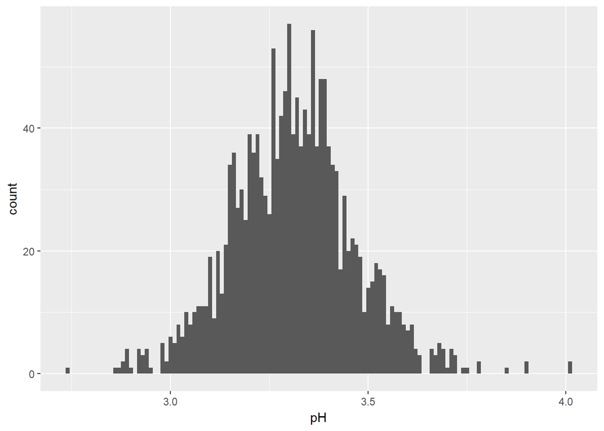

The distribution of pH is normal and concentrated around 3.310.

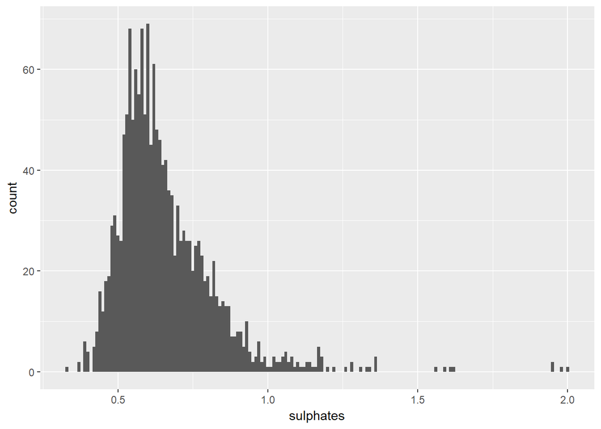

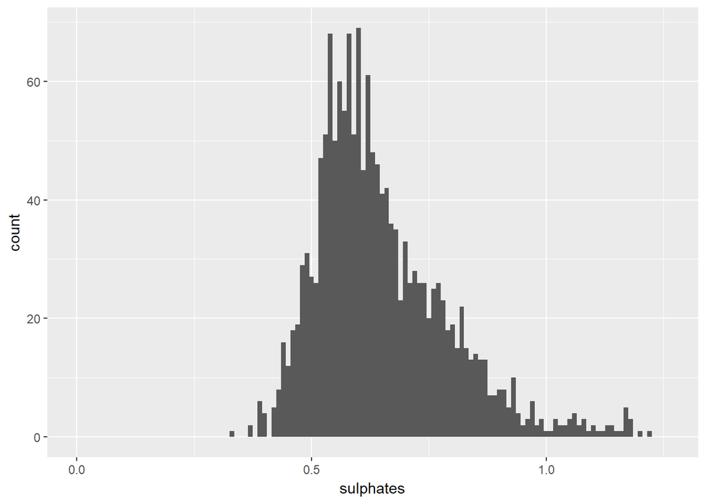

The distribution of sulphates is right skewed and concentrated around 0.6581. The second plot removed top 1 percent of outliers.

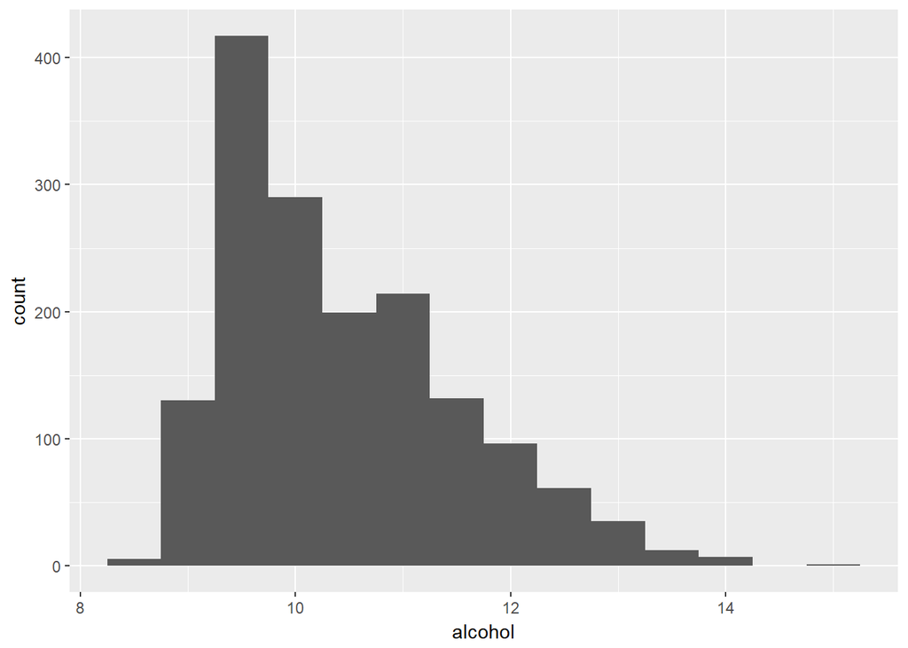

The distribution of alcohol is right skewed and concentrated around 10.20.

# Univariate Analysis

### What is the structure of your dataset?

There are 1,599 red wines in the dataset with 11 features on the chemical properties of the wine.

### What is/are the main feature(s) of interest in your dataset?

The main features in the data set are pH and quality. I’d like to determine which features are best for predicting the quality of a wine. I suspect pH and some combination of the other variables can be used to build a predictive model to grade the quality of wines.

### What other features in the dataset do you think will help support your investigation into your feature(s) of interest?

Volatile acidity, citric acid, and alcohol likely contribute to the quality of a wine. I think volatile acidity (the amount of acetic acid in wine) and alcohol (the percent alcohol content of the wine) probably contribute most to the quality after researching information on wine quality.

### Did you create any new variables from existing variables in the dataset?

I created a new variable called “quality.level” which is categorically divided into “low”, “average”, and “high”. This grouping method will help us detect the difference among each group more easily.

### Of the features you investigated, were there any unusual distributions? Did you perform any operations on the data to tidy, adjust, or change the form of the data? If so, why did you do this?

Having visualized acitric acid and volatile acidity data, I observed some unusual distributions, so I guess this fact may have some correlation with the quality of red wine. Since the data is clean, I did not perform any cleaning process or modification of the data.

# Bivariate Plots Section

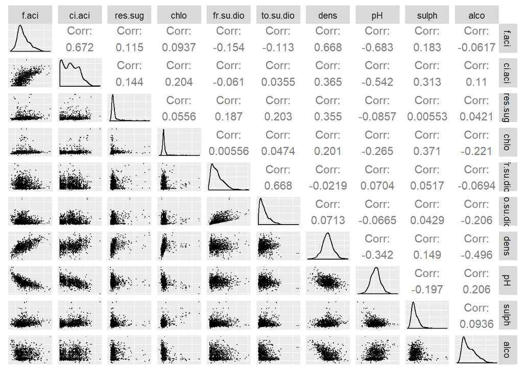

This correlation plot shows a positive relationship between density and fixed acidity, a positive relationship between fixed acidity and citric acid, and a negative relationship between pH and acidity. After this we can analyze the correlations between variables in more details.

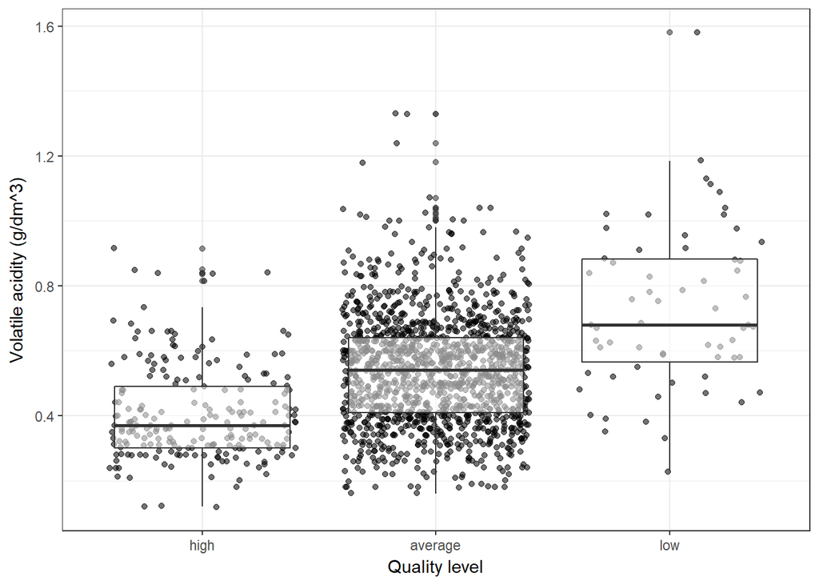

```
## [1] -0.3905578
```

The graph shows a very clear trend that the lower volatile acidity is, the higher the quality becomes. The correlation coefficient between quality and volatile acidity is -0.39. This can be explained by the fact that volatile acidity at too high of levels can lead to an unpleasant, vinegar taste.

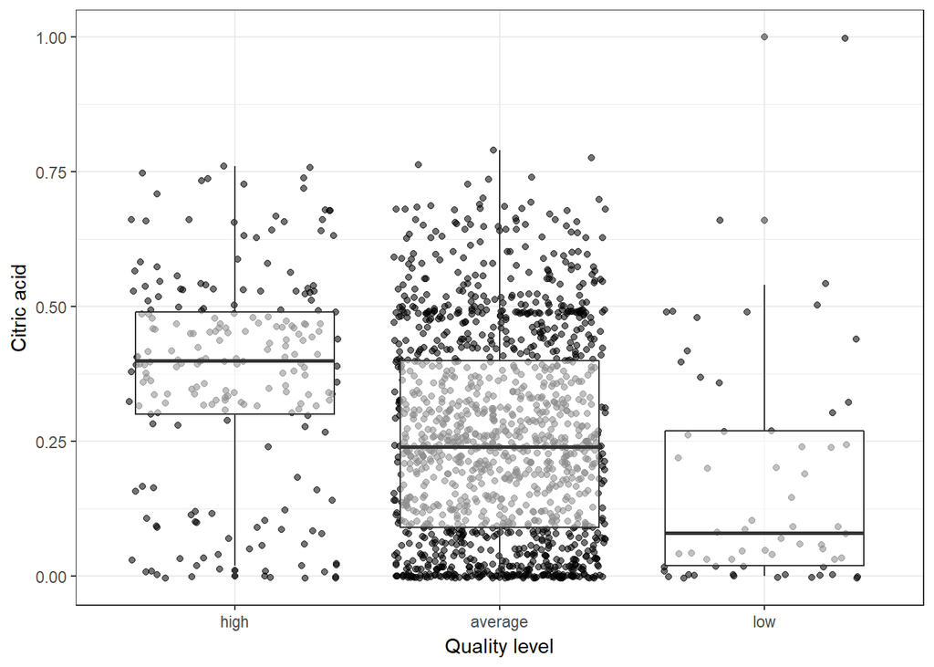

```
## [1] 0.2263725
```

The correlation coefficient is 0.226. The graph shows a weak positive relationship between quality level and citric acid.

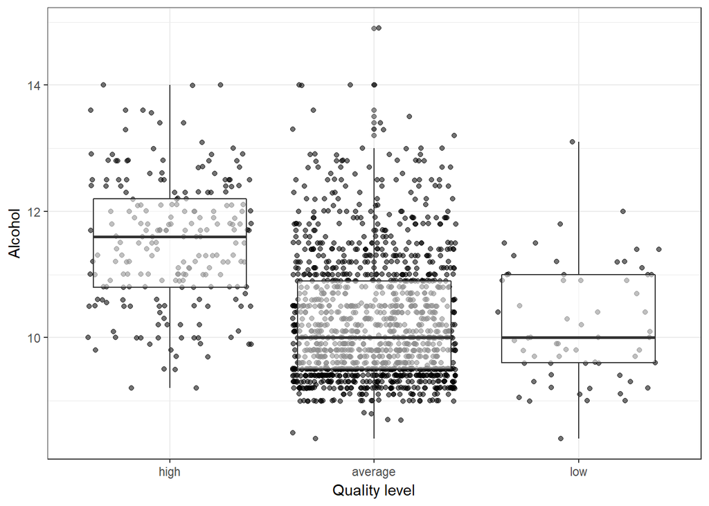

```
## [1] 0.4761663
```

With the correlation coefficient of 0.476, the graph shows a positive relationship between alcohol and quality level.

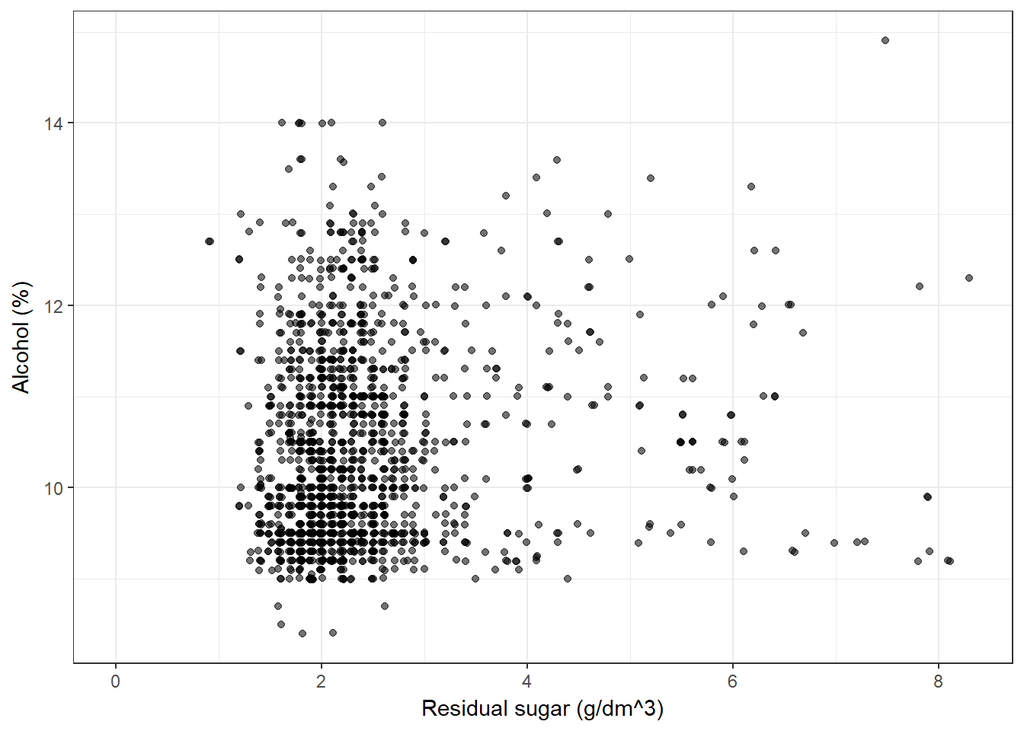

If we actually examine winemaking process, we see that there is a global trend for wines that are made from ripe to overly ripe grape fruit. To keep wines from staying too sweet, the fermentation process has to be left to continue until more of the sugar is consumed, but as a byproduct, more alcohol is present in the wines.

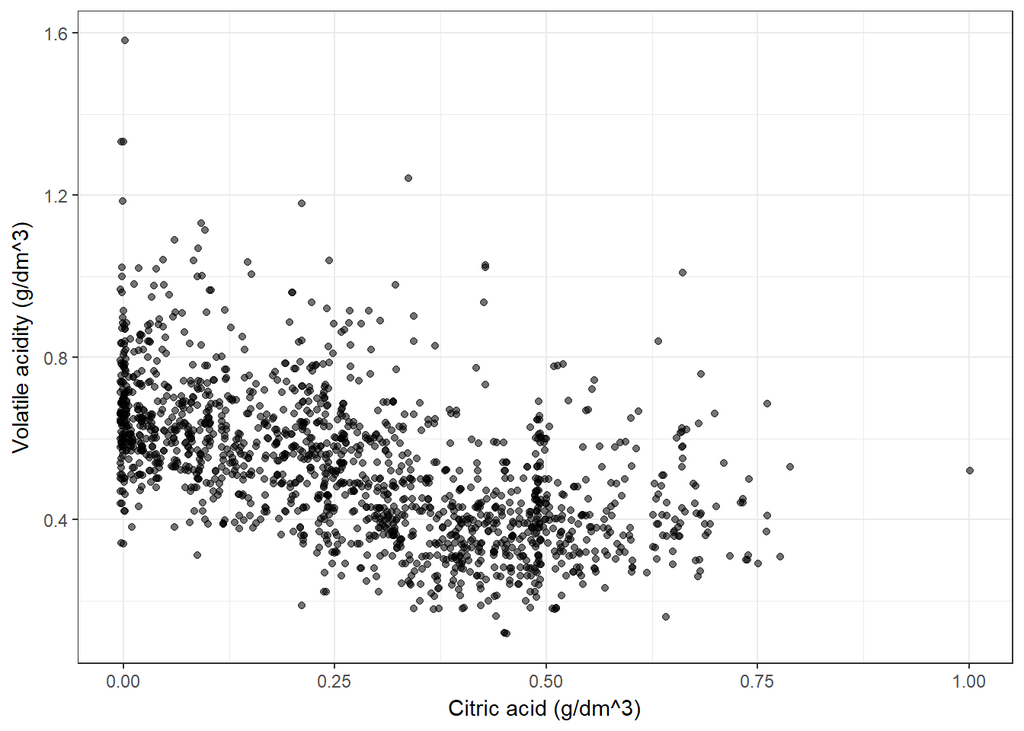

```
## [1] -0.5524957
```

There is a negative correlation between citric acid and volatile acidity.

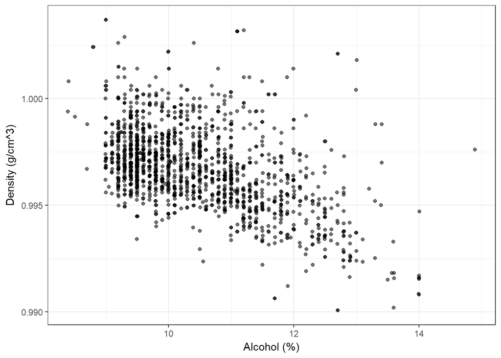

```
## [1] -0.4961798
```

The correlation coefficient is -0.50, so the relationship is quite clear. As percent of alcohol content increases, the density decreases. The reason is that the density of wine is lower than the density of pure water.

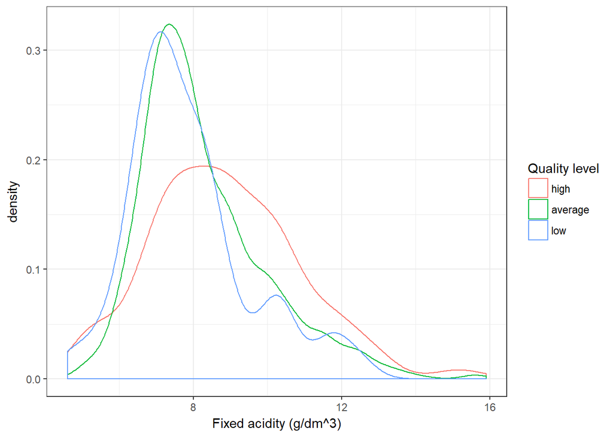

The distribution of low and average quality wines seem to be concentrated at fixed acidity values between 6 and 10. pH increases as fixed acidity decreases, and citric acid increases as fixed acidity increases.

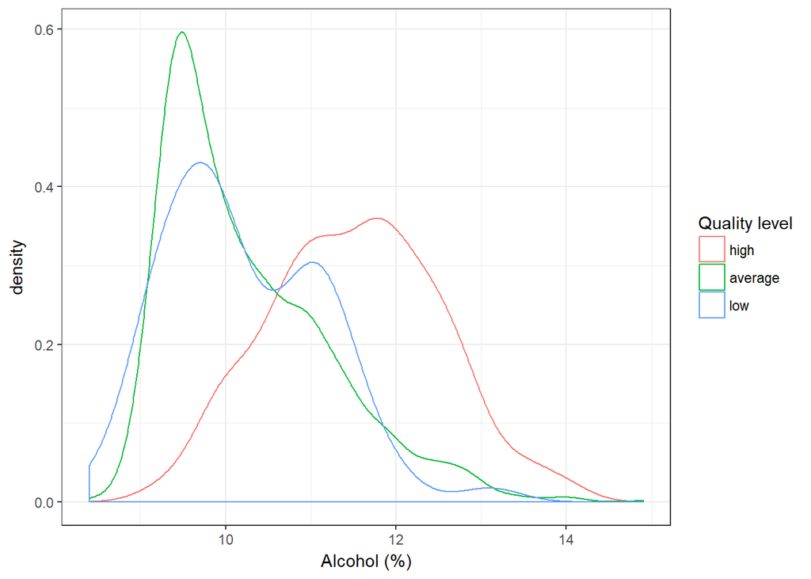

High quality wine density line is distinct from the others, and mostly distributed between 11 and 12.

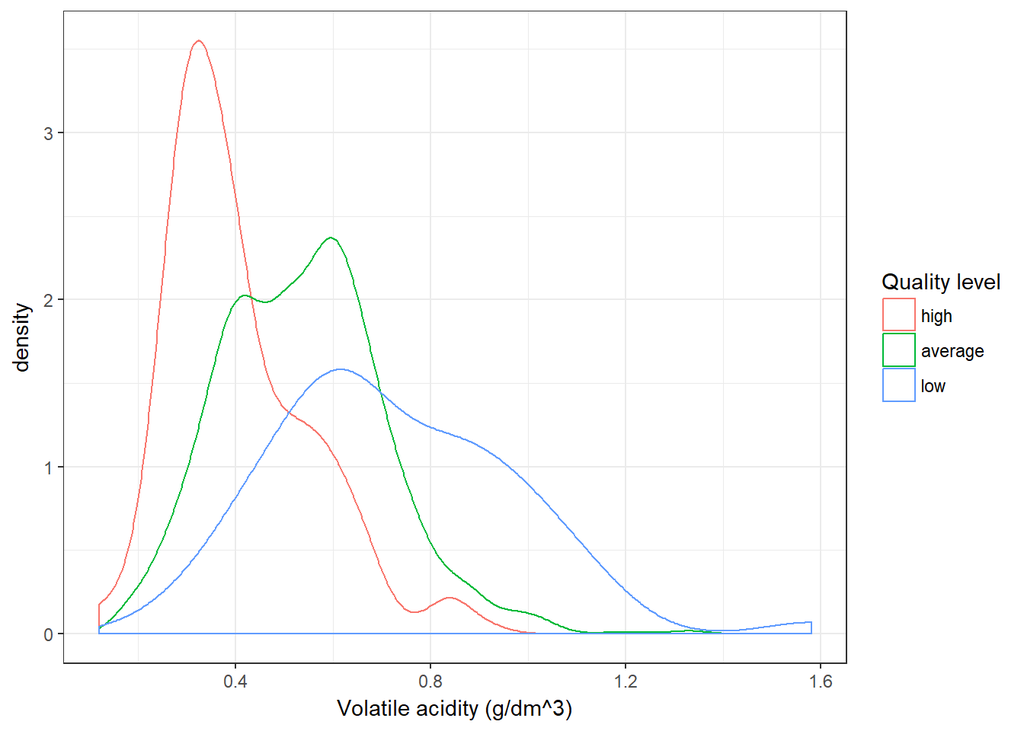

# Bivariate Analysis

### Talk about some of the relationships you observed in this part of the investigation. How did the feature(s) of interest vary with other features in the dataset?

I observed a negative relationship between quality level and volatile acidity, and a positive relationship between quality level and alcohol. I am not suprised at this result because men tend to grade stronger wines as high quality, whereas wines with low percent of alcohol are often not graded as such. High volatile acidity is also perceived to be undesirable because it impacts the taste of wines, which at too high of levels can lead to an unpleasant, vinegar taste according to the data information.

### Did you observe any interesting relationships between the other features (not the main feature(s) of interest)?

There is a positive relationship between density and fixed acidity, a positive relationship between fixed acidity and citric acid, and a negative relationship between pH and fixed acidity.

### What was the strongest relationship you found?

Quality is positively and strongly correlated with alcohol, and it is also negatively correlated with volatile acidity. Alcohol and volatile acidity could be used in a model to predict the quality of wine.

# Multivariate Plots Section

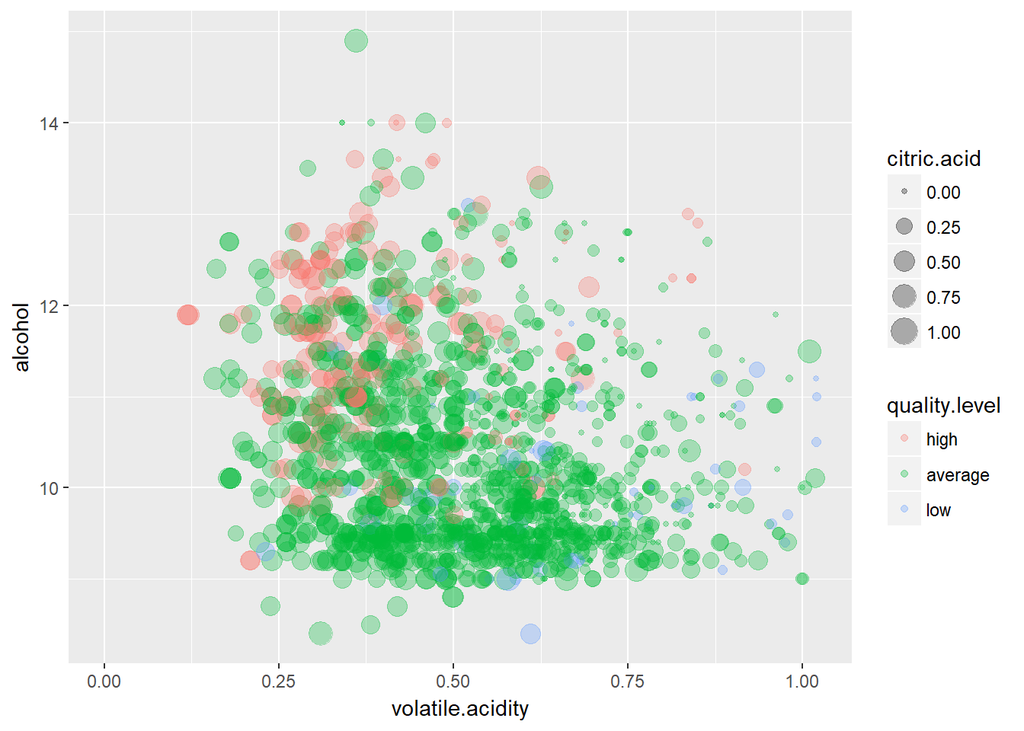

High quality feature seems to be associated with alcohol ranging from 11 to 13, volatile acidity from 0.2 to 0.5, and citric acid from 0.25 to 0.75

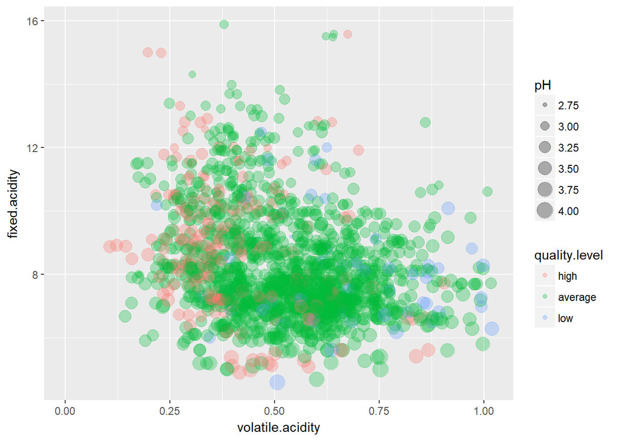

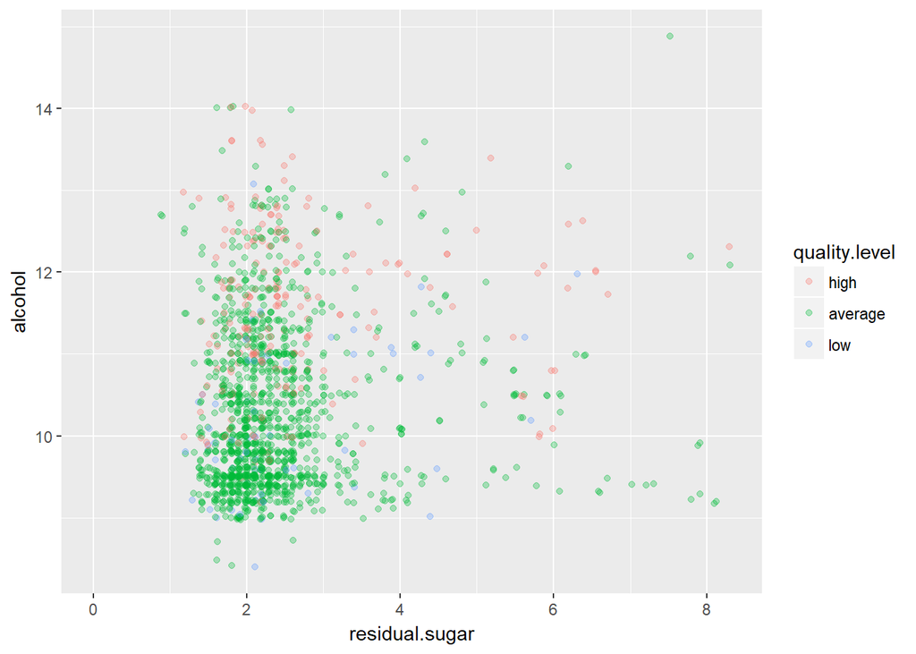

Residual sugar has no great effect on quality level.

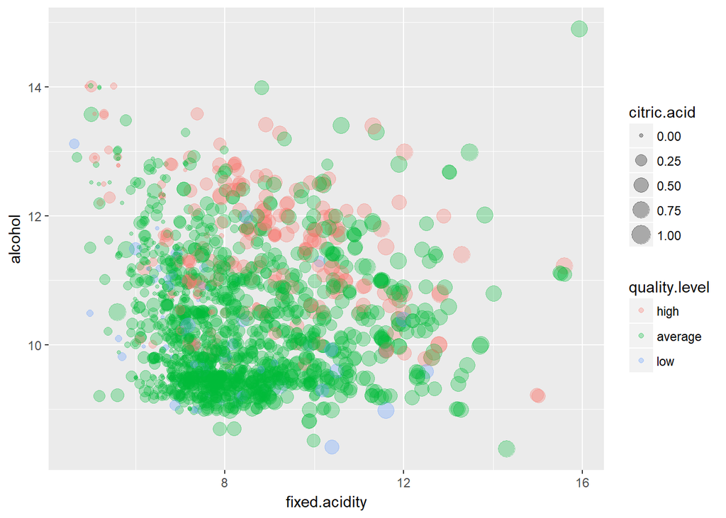